# 10a Clients

App Prototyping Studio

Mick McQuaid

mcq@utexas.edu

University of Texas at Austin

13 Oct 2026

# Week TEN

# Clients

[figure not shown]

[figure not shown]

# Greever (2020) on Clients

## The big meeting

- For the pitch meeting, communicating the designs was more important than the designs!
- Time spent designing was small compared to time spent preparing the pitches
- Client could have derailed the months-long effort in a minute

## What makes a good design good?

- Is it good use of space?
- Is it simplicity?
- Is it when you can’t remove anything?
- What do you think?

## None of these!

- Greever claims that these are internal to the designer and don’t respect the need to communicate
- Everyone is a designer in their own mind, just as everyone is a music critic even if they can’t play
- Good design is, to some degree, subjective (but there are design features like symmetry and tension that play across cultures and epochs)

[figure not shown]

## The power to say no

- Clients are not monolithic
- Many people may have the power to say no for different reasons
- They’re all stakeholders

## And yet, design by committee doesn’t work

- People disagree
- People get defensive when they disagree
- People fail to focus on the issues when they get defensive
- Grumbling compromise results

## Home page syndrome

- Home screens or pages become a catchall
- Different stakeholders believe *their* thing will work if it’s more prominent

## Communication is the job

- Most stakeholder issues can be explained as miscommunication or misunderstanding
- Designers must be communicators
- - Setting expectations
  - Following instructions
  - Articulating product and process

## What is “articulate”?

Understand your message *and* understand the desired response

## Being articulate includes

- Imparting intelligence $\Rightarrow$ trustworthiness
- Demonstrating intentionality $\Rightarrow$ purpose and focus
- Expressing confidence $\Rightarrow$ you mean what you say
- Showing respect $\Rightarrow$ plays well with others

## Greever’s definition of good design

- Solves a problem
- Easy for the users
- Supported by everyone

## By the way, my definition of good design is

When the client and users have no regrets, that is good design!

## Solving a problem

- Metrics matter
- What matters most to stakeholders?
- Introspection helps intuition
- Constantly ask how what you’re doing solves the problem
- Keep writing about the problem and solution

## Make it easy

- Ask how each thing you do affects the user (can’t always be sure)
- Write (and revise) a user story

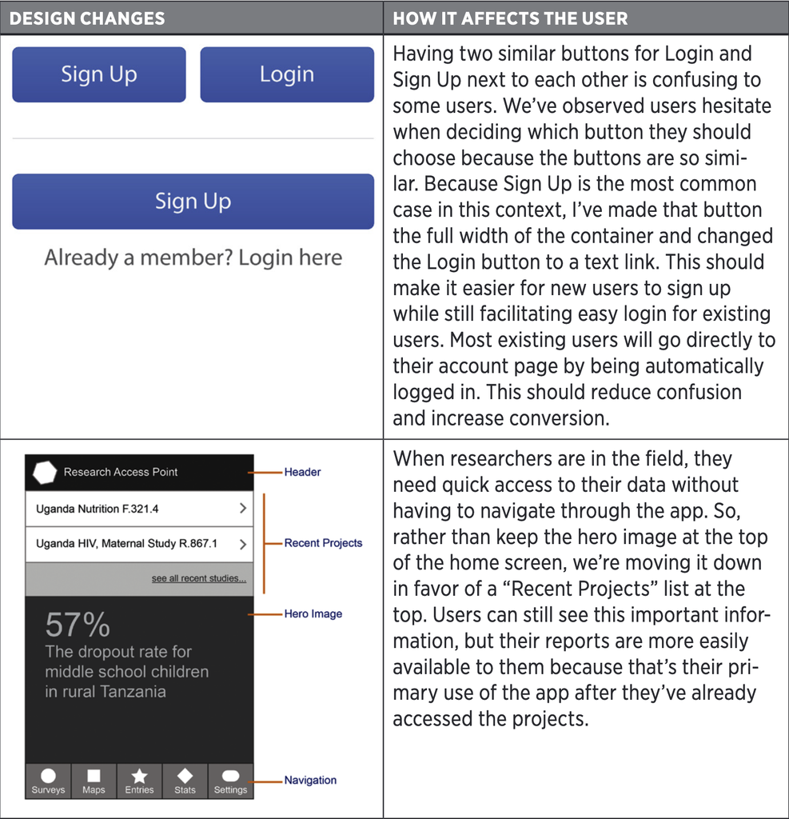

## Usability $=$ common sense $+$ research

## Get everyone’s support

- Not getting support means going over the same ground over and over
- Getting support is Greever’s primary focus
- Support $\neq$ agreement
- Get forward momentum, not consensus

## Ask over and over why this beats alternatives

- This means thinking of and thinking through alternatives
- This means anticipating how stakeholders will react
- It’s worth listing alternatives and problems they face
- Maybe wireframe alternatives

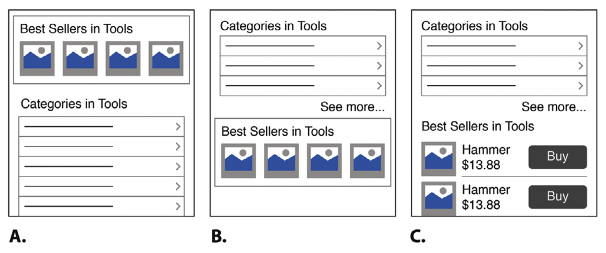

## Answer these questions

- What problem does it solve?
- How does it affect the user?
- Why is it better than the alternative?

# Greever (2020) on Stakeholders

## What you must do

- Improve stakeholder relationships
- Earn stakeholder trust
- Establish stakeholder rapport

## Apply UX principles to stakeholders

- Study stakeholders just as you study users
- Empathy for stakeholder
- Perspective of stakeholder

## Building the relationship

- See stakeholders as human
- Create shared experiences with stakeholders
- Develop empathy for stakeholders
- Ask good questions of stakeholders

# Mock client time

- Break into pairs
- One of you is the client
- Client conveys desire for shopping app to designer
- Designer tries to understand the client
- Client doesn’t have to make it easy!
- Switch roles
1. Take five minutes to prepare
2. During that time, client thinks about what they want in a shopping app
3. During that time, designer thinks about how they can elicit info
4. Come together for the interview
5. Repeat Steps 1–4

# END

# References

Greever, Tom. 2020. *Articulating Design Decisions: Communicate with Stakeholders, Keep Your Sanity, and Deliver the Best User Experience*. 2nd ed. O’Reilly Media.

# Colophon

This slideshow was produced using `quarto`

Fonts are *Fira Sans*, *Fira Sans Light*, and *Victor Mono Nerd Font*

Math is set in *Fira Math* via *MathJax 4*